# Mentoría: "Predicción de lluvias extremas"

- Grupo 1:
  - Florencia Balbuena
  - Sebastián Serantes
  - Diana Fonnegra
  - Laura Velazquez

# Análisis y Visualización de Datos

## Previsualización de datos:

```python
Datos.describe().T
```

|  | count | mean | std | min | 25% | 50% | 75% | max |
| --- | --- | --- | --- | --- | --- | --- | --- | --- |
| id | 249627.00 | 124814.00 | 72061.25 | 1.00 | 62407.50 | 124814.00 | 187220.50 | 249627.00 |
| omm_id | 249627.00 | 1010553.16 | 2899695.76 | 1.00 | 87328.00 | 87349.00 | 87467.00 | 9987015.00 |
| helio | 171930.00 | 7.08 | 3.85 | 0.00 | 4.30 | 8.10 | 10.00 | 19.10 |
| hr | 202229.00 | 67.17 | 15.47 | 7.00 | 57.00 | 68.00 | 79.00 | 100.00 |
| nub | 168343.00 | 3.70 | 2.62 | 0.00 | 1.00 | 4.00 | 6.00 | 8.00 |
| prcp | 232801.00 | 2.29 | 8.32 | 0.00 | 0.00 | 0.00 | 0.00 | 240.00 |
| pres_est | 166202.00 | 973.36 | 18.05 | 927.40 | 960.50 | 970.10 | 988.00 | 1026.70 |
| pres_nm | 130758.00 | 1013.79 | 6.51 | 989.90 | 1009.20 | 1013.30 | 1017.80 | 1042.60 |
| td | 202279.00 | 10.59 | 6.67 | -17.60 | 5.80 | 11.40 | 15.90 | 30.50 |
| tmax | 205391.00 | 24.40 | 6.54 | -0.40 | 19.60 | 24.80 | 29.40 | 45.10 |
| tmed | 168350.00 | 17.66 | 6.25 | -3.30 | 12.90 | 18.00 | 22.50 | 38.50 |
| tmin | 203718.00 | 11.13 | 6.27 | -13.00 | 6.60 | 11.80 | 16.10 | 31.70 |
| vmax_d | 160329.00 | 17.06 | 11.42 | 0.00 | 5.00 | 18.00 | 23.00 | 99.00 |
| vmax_f | 160366.00 | 8.04 | 4.87 | 0.00 | 4.10 | 7.20 | 10.80 | 88.50 |
| vmed | 198257.00 | 2.81 | 2.09 | 0.00 | 1.20 | 2.30 | 3.90 | 24.72 |
| caudal | 12497.00 | 90.24 | 91.56 | 10.20 | 43.46 | 61.95 | 101.87 | 1403.02 |

```python
Datos.head(5)
```

| fecha | id | omm_id | helio | hr | nub | prcp | pres_est | pres_nm | td | tmax | tmed | tmin | vmax_d | vmax_f | vmed | caudal |
| --- | --- | --- | --- | --- | --- | --- | --- | --- | --- | --- | --- | --- | --- | --- | --- | --- |
| 1961-01-01 | 1 | 87244 | NaN | 62.00 | 0.00 | 0.00 | 965.90 | NaN | 15.90 | 32.30 | 25.10 | 13.50 | NaN | NaN | 1.00 | NaN |
| 1961-01-02 | 2 | 87244 | NaN | 66.00 | 6.00 | 28.00 | 969.90 | NaN | 15.50 | 27.50 | 22.20 | 18.30 | NaN | NaN | 1.00 | NaN |
| 1961-01-03 | 3 | 87244 | NaN | 92.00 | 8.00 | 15.40 | 972.60 | NaN | 13.10 | 21.70 | 14.40 | 12.90 | NaN | NaN | 4.50 | NaN |
| 1961-01-04 | 4 | 87244 | NaN | 84.00 | 5.00 | 0.00 | 969.60 | NaN | 17.40 | 23.10 | 20.40 | 13.90 | NaN | NaN | 0.30 | NaN |
| 1961-01-05 | 5 | 87244 | NaN | 84.00 | 5.00 | 3.60 | 965.60 | NaN | 17.80 | 23.90 | 20.70 | 15.50 | NaN | NaN | 1.50 | NaN |

```python
Datos.tail(5)
```

| fecha | id | omm_id | helio | hr | nub | prcp | pres_est | pres_nm | td | tmax | tmed | tmin | vmax_d | vmax_f | vmed | caudal |
| --- | --- | --- | --- | --- | --- | --- | --- | --- | --- | --- | --- | --- | --- | --- | --- | --- |
| 2017-08-29 | 249623 | 2 | NaN | NaN | NaN | NaN | NaN | NaN | NaN | NaN | NaN | NaN | NaN | NaN | NaN | 49.50 |
| 2017-08-30 | 249624 | 2 | NaN | NaN | NaN | NaN | NaN | NaN | NaN | NaN | NaN | NaN | NaN | NaN | NaN | 48.94 |
| 2017-08-31 | 249625 | 2 | NaN | NaN | NaN | NaN | NaN | NaN | NaN | NaN | NaN | NaN | NaN | NaN | NaN | 48.33 |
| 2017-09-01 | 249626 | 2 | NaN | NaN | NaN | NaN | NaN | NaN | NaN | NaN | NaN | NaN | NaN | NaN | NaN | 47.73 |
| 2017-09-02 | 249627 | 2 | NaN | NaN | NaN | NaN | NaN | NaN | NaN | NaN | NaN | NaN | NaN | NaN | NaN | 47.24 |

# Descripción de datasets:

- **Datos:** contiene los datos meteorologicos registrados para cada estación de la OMM. Los datos son los siguientes:
  - helio: horas diarias del sol (horas).
  - hr: humedad relativa (%).
  - nub: cobertura nubosa (octavos).
  - prcp: precipitación acumulada (milímetros "mm").
  - pres_est: presión al nivel de la estación (hectopascales "hpa").
  - pres_nm: presión al nivel del mar (hectopascales "hpa").
  - td: temperatura de rocio (Grados Celsius).
  - tmax: temperatura máxima (Grados Celsius).
  - tmed: temperatura media (Grados Celsius).
  - tmin: temperatura mínima (Grados Celsius).
  - vmax_d: dirección del viento máximo (decenas de grado).
  - vmax_f: velocidad del viento máxima (metros por segundo "m/s").
  - vmed: velocidad del viento media (metros por segundo "m/s").
  - caudal: caudal que escurre por el rio (solo algunas estaciones tienen esta informacion, en metros cúbicos por segundo "m3/s").

```python
id_Datos[:3]
```

|  | id | omm_id | nombre | lon_grad | lon_min | lon_seg | lon_hem | lat_grad | lat_min | lat_seg | ... | lon_dec | lat_dec | elev | institucion_id | nivel_adm1 | nivel_adm2 | fecha_inicio | tipo | pais_id | siglas |
| --- | --- | --- | --- | --- | --- | --- | --- | --- | --- | --- | --- | --- | --- | --- | --- | --- | --- | --- | --- | --- | --- |
| 0 | 1 | 87244 | Villa Maria del Rio Seco | 63 | 43 | 39.31 | W | 29 | 54 | 20.90 | ... | -63.73 | -29.91 | 341 | 1 | Cordoba | Rio Seco | 1/10/1903 | C | AR | SMN |
| 1 | 2 | 87328 | Villa Dolores Aero | 65 | 8 | 56.54 | W | 31 | 57 | 4.66 | ... | -65.15 | -31.95 | 569 | 1 | Cordoba | San Javier | 1/10/1903 | C | AR | SMN |
| 2 | 3 | 87344 | Cordoba Aero | 64 | 12 | 42.67 | W | 31 | 17 | 47.87 | ... | -64.21 | -31.30 | 474 | 1 | Cordoba | Colon | 1/1/1946 | C | AR | SMN |

3 rows × 21 columns

# Descripción de datasets:

- **id_Datos:** contiene todos los datos de ubicación (latitud, longitud, altura, provincia, departamento (adm2), etc) de las estaciones en la provincia de Córdoba que iremos a analizar. Estos se vinculan con la tabla "Datos" mediante la columna "omm_id" que es el número de id segun la Organización Meteorológica Mundial.

## 1.1 Box-Plot->

Para la realización de los boxplots se ejecutaron pasos como:

- Crear una copia del conjunto de datos de estaciones
- Definir un diccionario de datos que tome como *key* el valor de la codificación de la OMM y como *value* el nombre que etiqueta la misma.
- Definir un diccionario de datos que tome como *key* el valor de la codificación de la OMM y como *value* el dato de elevación en la que se ubica la estación.
- Gráficar en formato de Boxplot cada una de las variables que se encuentran en el conjunto de datos por estación.

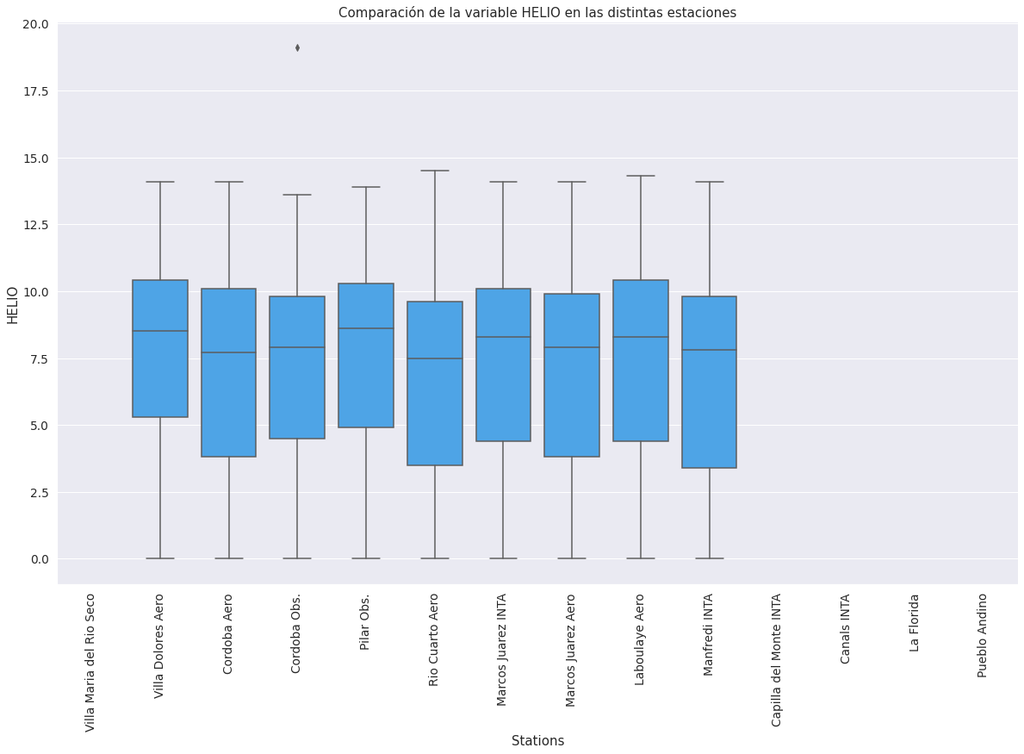

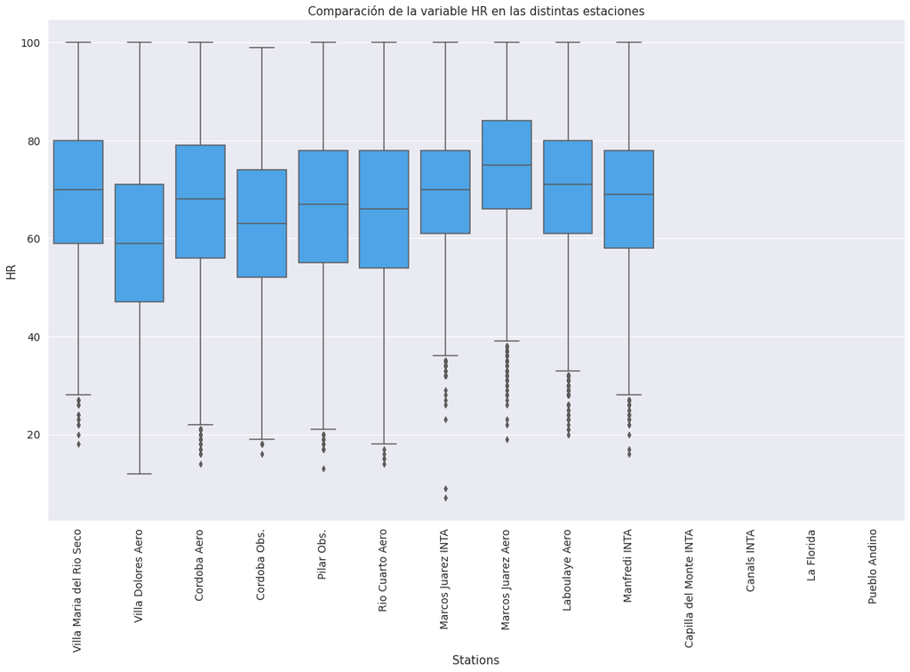

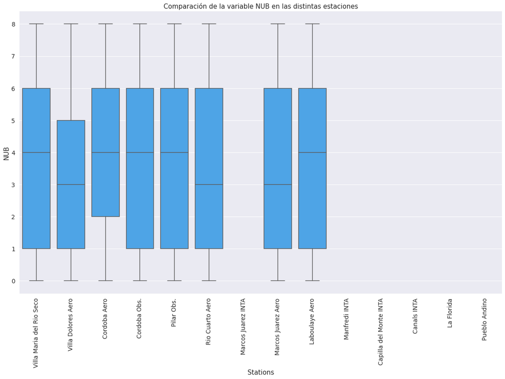

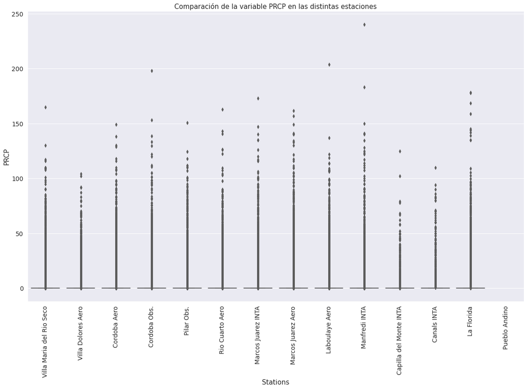

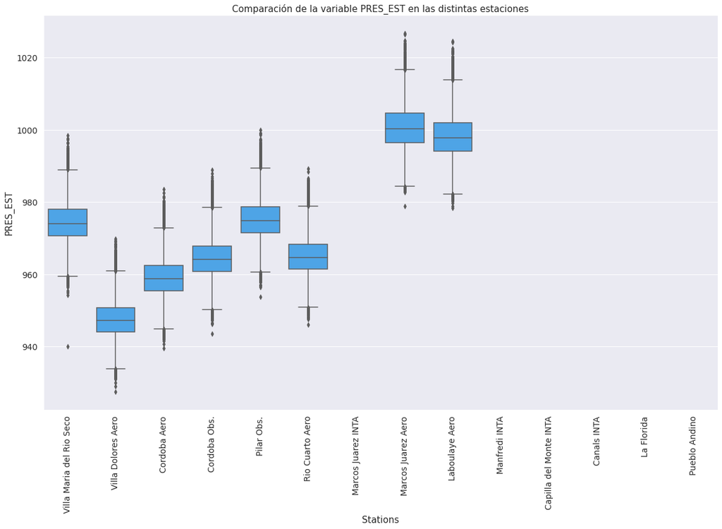

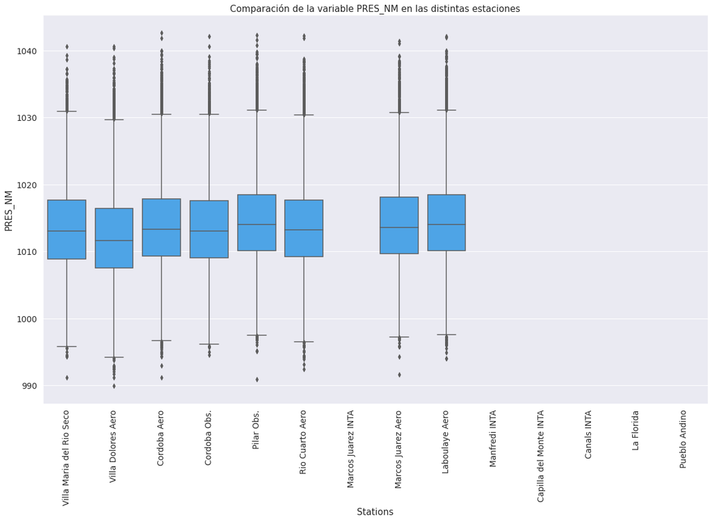

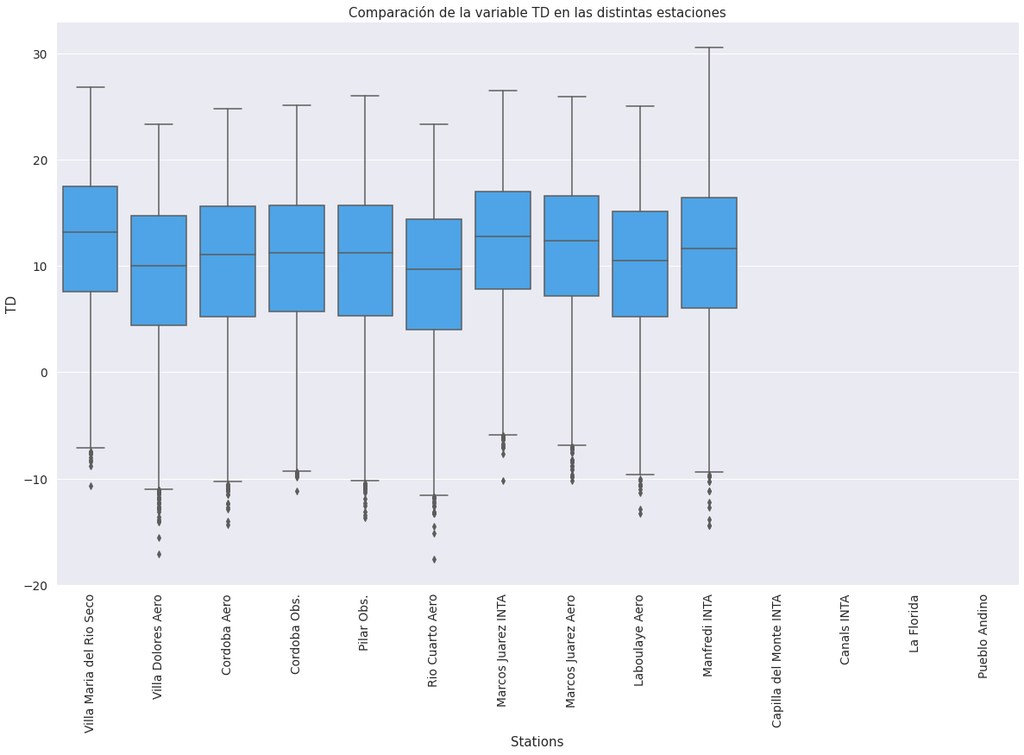

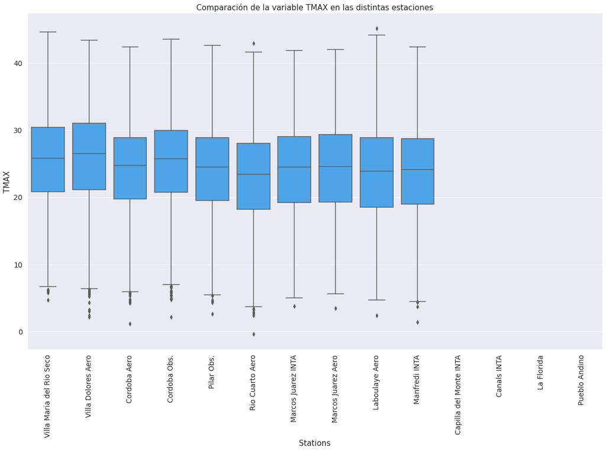

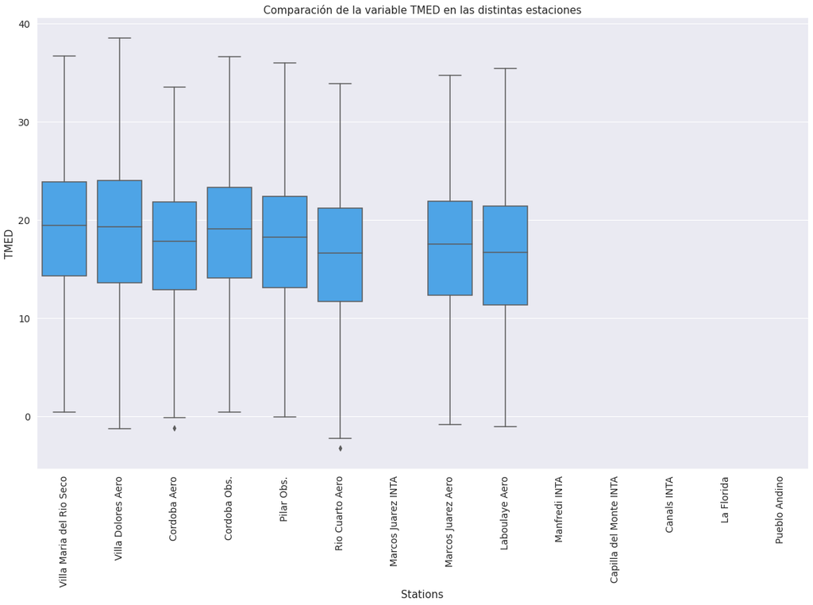

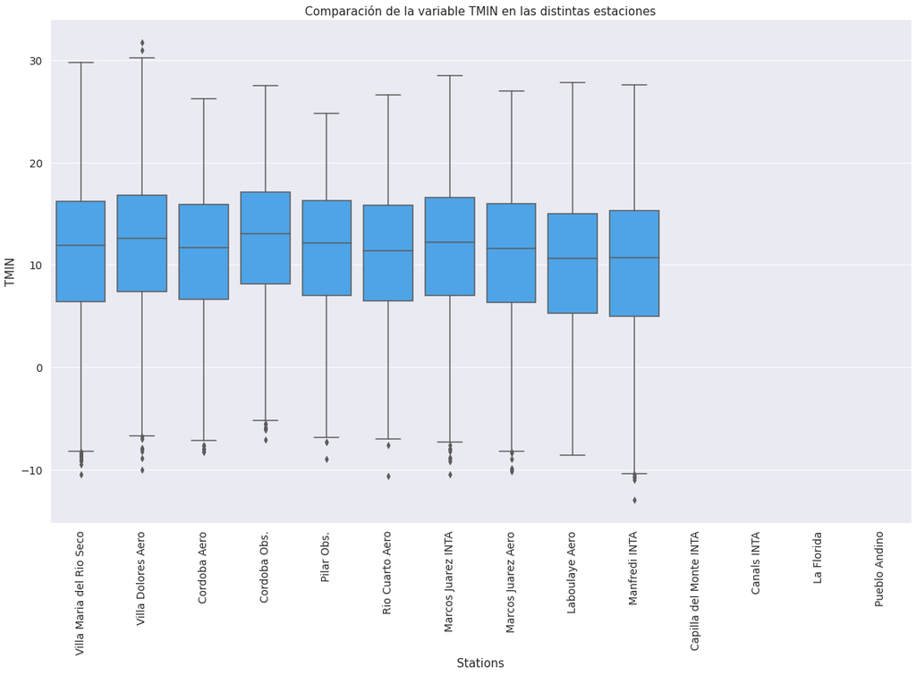

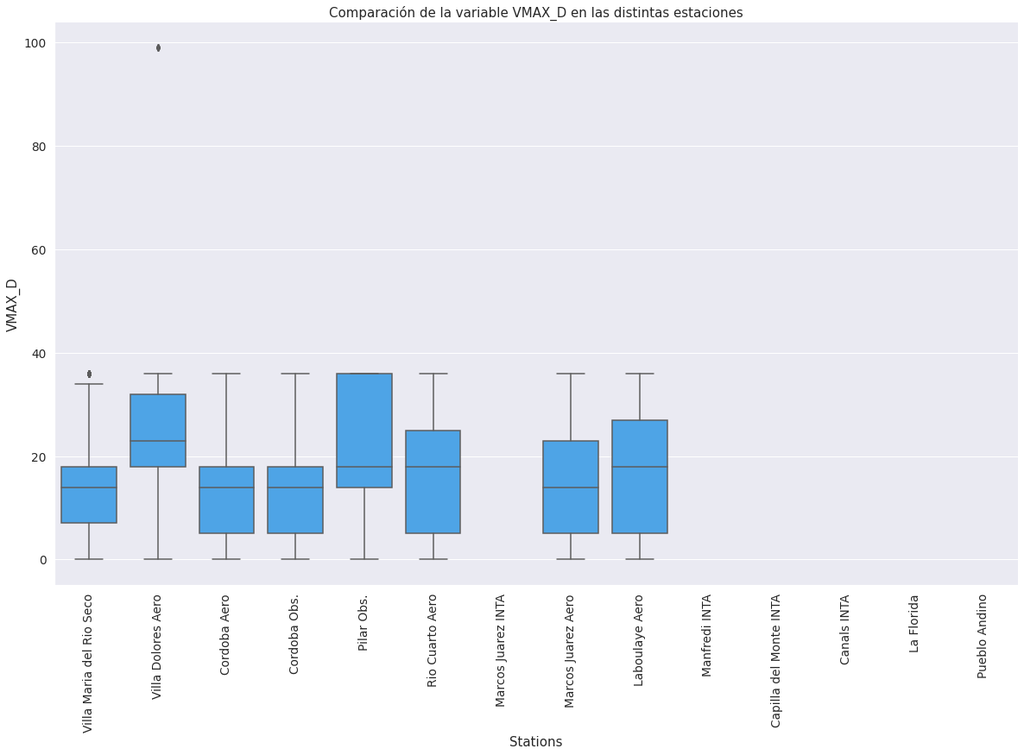

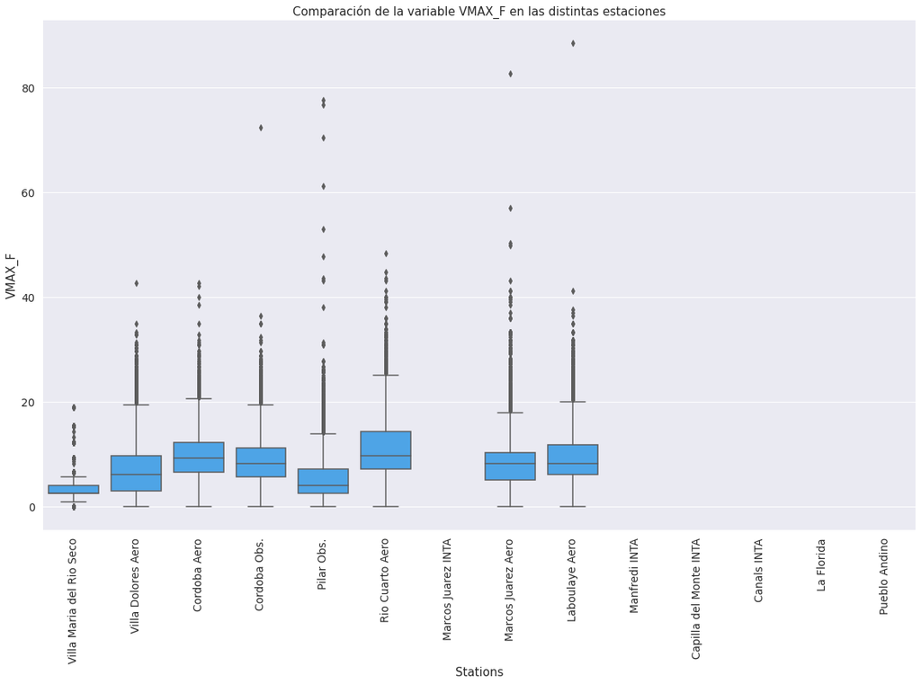

[2 more figures not shown]

```python
BLUE = '#35A7FF'
RED = '#FF5964'
GREEN = '#6BF178'
YELLOW = '#FFE74C'

dataset_with_stations = dataset.copy()
dataset_with_stations['station'] = dataset_with_stations['omm_id'].replace(stations)
dataset_with_stations.reset_index(inplace=True)
not_numeric_cols = ['fecha', 'id', 'omm_id', 'station']
numeric_cols = [c for c in dataset_with_stations.columns if c not in not_numeric_cols]
for numeric_col in numeric_cols:
    plt.figure(figsize=(20,12))
    sns.boxplot(data=dataset_with_stations,
                    x='station', y=numeric_col,
                    color=BLUE)
    plt.ylabel(numeric_col.upper())
    plt.xlabel('Stations')
    plt.title(f'Comparación de la variable {numeric_col.upper()} en las distintas estaciones')
    plt.xticks(rotation=90)
    sns.despine()
```

## Calcular el rango de las variables de cada estación.

```python
dataset_with_stations = dataset.copy()
dataset_with_stations['station'] = dataset_with_stations['omm_id'].replace(stations)
dataset_with_stations.reset_index(inplace=True)
not_numeric_cols = ['fecha', 'id', 'omm_id', 'station']
numeric_cols = [c for c in dataset_with_stations.columns if c not in not_numeric_cols]

for station in dataset_with_stations['station'].unique():
  subdf = dataset_with_stations.loc[dataset_with_stations['station']==station,:]
  print(f'\nPara la estación <<{station}>>:\n')

  for count, value in enumerate(subdf.columns):
    if value not in not_numeric_cols:

      globals()[f'{value}_min'] = round(subdf[value].min(skipna=True),2)
      globals()[f'{value}_max'] = round(subdf[value].max(skipna=True),2)
      globals()[f'{value}_range'] = round(eval(f'{value}_max- {value}_min'),2)
      print(f'Rango para la variable {value} = ',eval(f'{value}_range'))
```

```
Para la estación <<Villa Maria del Rio Seco>>:

Rango para la variable helio =  nan
Rango para la variable hr =  82.0
Rango para la variable nub =  8.0
Rango para la variable prcp =  165.0
Rango para la variable pres_est =  58.5
Rango para la variable pres_nm =  49.4
Rango para la variable td =  37.5
Rango para la variable tmax =  39.9
Rango para la variable tmed =  36.3
Rango para la variable tmin =  40.3
Rango para la variable vmax_d =  36.0
Rango para la variable vmax_f =  19.0
Rango para la variable vmed =  11.3
Rango para la variable caudal =  nan

Para la estación <<Villa Dolores Aero>>:

Rango para la variable helio =  14.1
Rango para la variable hr =  88.0
Rango para la variable nub =  8.0
Rango para la variable prcp =  104.0
Rango para la variable pres_est =  42.4
Rango para la variable pres_nm =  50.7
Rango para la variable td =  40.4
Rango para la variable tmax =  41.2
Rango para la variable tmed =  39.8
Rango para la variable tmin =  41.7
Rango para la variable vmax_d =  99.0
Rango para la variable vmax_f =  42.7
Rango para la variable vmed =  17.1
Rango para la variable caudal =  nan

Para la estación <<Cordoba Aero>>:

Rango para la variable helio =  14.1
Rango para la variable hr =  86.0
Rango para la variable nub =  8.0
Rango para la variable prcp =  149.0
```

[output cut: 182 more lines]

```

Rango para la variable helio =  nan
Rango para la variable hr =  nan
Rango para la variable nub =  nan
Rango para la variable prcp =  nan
Rango para la variable pres_est =  nan
Rango para la variable pres_nm =  nan
Rango para la variable td =  nan
Rango para la variable tmax =  nan
Rango para la variable tmed =  nan
Rango para la variable tmin =  nan
Rango para la variable vmax_d =  nan
Rango para la variable vmax_f =  nan
Rango para la variable vmed =  nan
Rango para la variable caudal =  1392.82
```

## Agregación de datos

```python
def get_hydro_year(date_, start_month=7):
    year = date_.strftime('%Y')
    month = date_.strftime('%m')
    offset = 1 if int(month) >= start_month - 1 else 0
    hydro_year = int(year) + offset - 1
    return hydro_year
```

### * Se crea un nuevo conjunto de datos, en el se agregaran el nombre de la estación y la elevación correspondiente:

### * Luego a partir del año hidrológico, se agrupa la información dada la acumulación anual de los datos de prcp (Precipitación Total Anual o PTA).

```python
prcp_mean_by_hydro_year_and_station = dataset_with_hydro_year.groupby(['hydro_year', 'omm_id']).sum()\
['prcp'].groupby(['omm_id']).mean()

#Transformo a diccionario de datos key: omm_id y value: prcp/año
prcp_mean_by_hydro_year_and_station_dict = prcp_mean_by_hydro_year_and_station.to_frame().to_dict()
stations_df_prcp_mean = stations_dataset.copy()

stations_df_prcp_mean['prcp_mean'] = stations_dataset['omm_id'].replace(prcp_mean_by_hydro_year_and_station_dict['prcp'])

# Extrayendo un subconjunto con las variables de interés:
stations_df_prcp_mean[['omm_id', 'nombre', 'elev', 'prcp_mean']]
```

|  | omm_id | nombre | elev | prcp_mean |
| --- | --- | --- | --- | --- |
| 0 | 87244 | Villa Maria del Rio Seco | 341 | 786.34 |
| 1 | 87328 | Villa Dolores Aero | 569 | 610.99 |
| 2 | 87344 | Cordoba Aero | 474 | 835.31 |
| 3 | 87345 | Cordoba Obs. | 426 | 786.16 |
| 4 | 87349 | Pilar Obs. | 338 | 766.56 |
| 5 | 87466 | Marcos Juarez INTA | 110 | 887.98 |
| 6 | 87453 | Rio Cuarto Aero | 421 | 826.91 |
| 7 | 87467 | Marcos Juarez Aero | 114 | 910.68 |
| 8 | 87534 | Laboulaye Aero | 137 | 873.28 |
| 9 | 9987009 | Manfredi INTA | 292 | 771.65 |
| 10 | 9987013 | Capilla del Monte INTA | 984 | 564.32 |
| 11 | 9987015 | Canals INTA | 125 | 767.53 |
| 12 | 1 | La Florida | 1090 | 845.86 |
| 13 | 2 | Pueblo Andino | 9 | 0.00 |

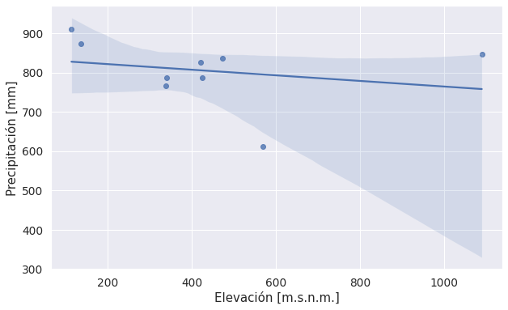

```python
plt.figure(figsize=(10,6))

ex = ['Pueblo Andino', 'Marcos Juarez INTA', 'Manfredi INTA', 'Capilla del Monte INTA', 'Canals INTA']

stations_df_prcp_mean_filtered = stations_df_prcp_mean[~stations_df_prcp_mean.nombre.isin(ex)]

ax = sns.regplot(x="elev", y="prcp_mean", data=stations_df_prcp_mean_filtered, dropna=True)
plt.ylabel('Precipitación [mm]')
plt.xlabel("Elevación [m.s.n.m.]")
```

### * Determinando la temperatura media diaria anual (TMedDA) de cada estación y generando el gráfico de tendencias:

```python
tmed_mean_by_hydro_year_and_station = dataset_with_hydro_year.groupby(['hydro_year', 'omm_id']).mean()\
['tmed'].groupby(['omm_id']).mean()

#Transformo a diccionario de datos key: omm_id y value: tmed/año
tmed_mean_by_hydro_year_and_station_dict = tmed_mean_by_hydro_year_and_station.to_frame().to_dict()
stations_df_tmed_mean = stations_dataset.copy()

stations_df_tmed_mean['tmed_mean'] = stations_dataset['omm_id'].replace(tmed_mean_by_hydro_year_and_station_dict['tmed'])

# Extrayendo un subconjunto con las variables de interés:
stations_df_tmed_mean[['omm_id', 'nombre', 'elev', 'tmed_mean']]
```

|  | omm_id | nombre | elev | tmed_mean |
| --- | --- | --- | --- | --- |
| 0 | 87244 | Villa Maria del Rio Seco | 341 | 19.06 |
| 1 | 87328 | Villa Dolores Aero | 569 | 18.75 |
| 2 | 87344 | Cordoba Aero | 474 | 17.27 |
| 3 | 87345 | Cordoba Obs. | 426 | 18.71 |
| 4 | 87349 | Pilar Obs. | 338 | 17.76 |
| 5 | 87466 | Marcos Juarez INTA | 110 | NaN |
| 6 | 87453 | Rio Cuarto Aero | 421 | 16.38 |
| 7 | 87467 | Marcos Juarez Aero | 114 | 17.03 |
| 8 | 87534 | Laboulaye Aero | 137 | 16.42 |
| 9 | 9987009 | Manfredi INTA | 292 | NaN |
| 10 | 9987013 | Capilla del Monte INTA | 984 | NaN |
| 11 | 9987015 | Canals INTA | 125 | NaN |
| 12 | 1 | La Florida | 1090 | NaN |
| 13 | 2 | Pueblo Andino | 9 | NaN |

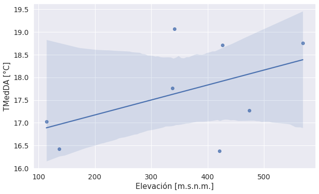

```python
plt.figure(figsize=(10,6))

ex = ['Pueblo Andino', 'Marcos Juarez INTA', 'Manfredi INTA', 'Capilla del Monte INTA', 'Canals INTA']
stations_df_tmed_mean_filtered = stations_df_tmed_mean[~stations_df_tmed_mean.nombre.isin(ex)]

ax = sns.regplot(x="elev", y="tmed_mean", data=stations_df_tmed_mean_filtered, dropna=True)
plt.ylabel('TMedDA [°C]')
plt.xlabel("Elevación [m.s.n.m.]")
```